# DESeq Analysis - 30 min data

Merrimack College DSE6630: Healthcare & Life Sciences Analytics

Katherine S. Geist, PhD

22 April 2024

# Introduction

This code creates the Variance-Stabilizing Transformed (VST) data for the 30-min data for the **benchmarking study** we are doing with the bumblebee chill-coma data. This is for students doing this for their Project 1 - **but you do not need to run this code**. The results have been provided to you.

## Sample Metadata

**Metadata** refers to information about sequencing files that describe the samples. This can include information about how the samples were collected, the **phenotypes** of the samples (the traits, physical or behavioral, that are thought to be at least partially controlled by gene expression diversity), and IDs for individuals or, in this case, colonies from which the data come.

Table 1. Metadata of the gene expression samples.

| Variable | Description |
| --- | --- |
| sampleID | The original ID of the sequencing sample obtained |
| Colony | The bumblebee colony from which the indiduals sampled came |
| Treatment | Control vs. Chill Exposure |
| Time | Duration of the treatment |

- We only want the samples for the 30-min experiment, so we will filter for that.

```
## [1] "There are 16 samples in the 30-min experiment."
```

## Read Counts

We will be working with the **raw count** data as **CPM (read counts per million)** from just the 16 samples from the 30-min experiment to perform a DEG analysis.

- Let’s read in the raw counts and filter for just the 30-min samples.

```
## [1] "There are 16 samples in the columns of the counts dataset with 12924 genes in the rows."
```

# Conventional Method: Differential Expression Analysis using `DESeq2`

The Bioconductor package `DESeq2` is one of several such packages that exist in R, but has rapidly become one of the ‘gold standards’ for DE analyses. You can find more about how this package is used by looking at the [vignette](http://bioconductor.org/packages/devel/bioc/vignettes/DESeq2/inst/doc/DESeq2.html).

## Pre-processing the counts data and metadata

In short, `DESeq2` reads in the raw counts as a matrix, which must then be converted to a **design matrix** which includes the sample metadata for each column. Importantly, matrices should **not** contain the IDs in a column, but should be move to the **row names** of the matrix instead.

```
## [1] "The column names of the counts matrix are present in the row names of the metadata: TRUE"
```

```
## [1] "The names are in the same order: TRUE"
```

## Make the `DESeq` Design Object

Next, make the **design object**, which contains your **model formula** for analysis; the design formula here should **not** include time. `Treatment` is placed at the end of the formula as it is the variable of interest. We are making a `DESeqDataSet` object class used by `DeSeq2` to store the read counts, metadata, and design formula.

```r
dsgnObject <- DESeqDataSetFromMatrix(countData = counts,
                                     colData = metadata,
                                     design = ~ Colony + Treatment)
dim(dsgnObject)
```

```
## [1] 12924    16
```

## Normalization: Variance-Stabilizing Transformation

As we currently still have raw counts in the design object, we will apply a **variance stabilizing** transformation with a parametric fit with the variance stabilizing transform (VST). Note that all transformations have set `blind = FALSE`. We do not want the transformations to be blind to the experimental design (treatment) at this point; we expect large differential expression in some genes. Thus, we need to control for outliers by setting `blind = FALSE`.

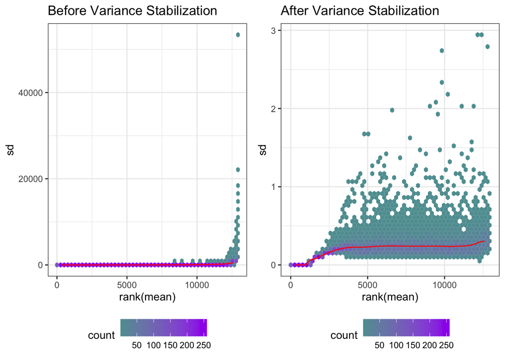

```
## class: DESeqTransform
## dim: 12924 16
## metadata(1): version
## assays(1): ''
## rownames(12924): LOC100740276 LOC100740157 ... LOC112214039
##   LOC100742283
## rowData names(6): baseMean baseVar ... dispGeneIter dispFit
## colnames(16): C30ECK10 C30ECK11 ... T30ECK101 T30ECK102
## colData names(4): Colony Treatment Time sizeFactor
```

## Wald Tests for significant differential expression between conditions

The `DESeq()` function does two things roughly simultaneously. It performs normalization (median of ratios) to corrects for variance in read sequencing depth & inter-library dispersion in counts (for each gene). It also calculates the significance of coefficients with a negative binomial GLM. We will also return log-fold change for each gene based on our design formula.

##### Estimate the size factors.

A **size factor** is effectively a count of how many reads there are in each library, sample, or batch (it can depend on the design). This is to account for those batch-level effects.

Examine how well the scaling/normalization has worked across all of the samples:

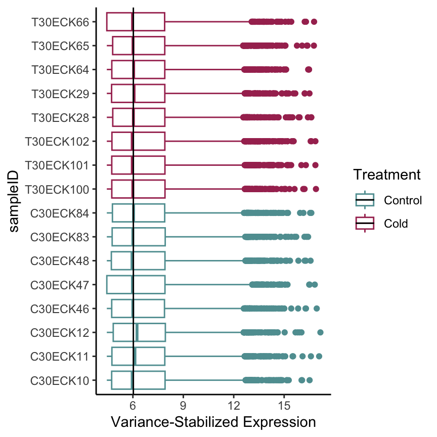

Run the Wald tests:

```
##
## out of 11650 with nonzero total read count
## adjusted p-value < 0.05
## LFC > 0 (up)       : 34, 0.29%
## LFC < 0 (down)     : 13, 0.11%
## outliers [1]       : 71, 0.61%
## low counts [2]     : 2682, 23%
## (mean count < 3)
## [1] see 'cooksCutoff' argument of ?results
## [2] see 'independentFiltering' argument of ?results
```

Not bad! Using the Wald test, we found 34 up-regulated and 13 down-regulated genes for a total of **47 differentially expressed genes.**

# Exploratory Data Analysis

## Summary statistics on the raw gene (feature) counts

Summary statistics of the raw gene expression counts, Time: 30 min

|  | All Samples |
| --- | --- |
| Total Genes | 12924 |
| Number Genes with >1 read count | 11650 |
| Proportion with Nonzero Expression | 0.9014 |
| Proportion with Low Expression | 0.3919 |
| Number Reads: Cold-Expossed Treatment | 33498905 |
| Number Reads: Control Treatment | 36498659 |
| Total Reads Mapped | 69997564 |
| N Samples | 16 |
| Mean CPM per Sample | 4.37 |

## Heatmap of gene expression across treatments & time points

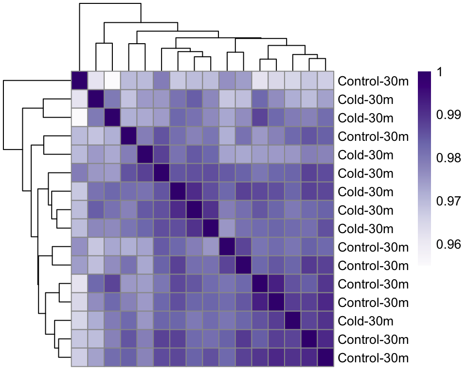

This time we are seeing some more clustering of the chill-come and control samples, although it’s still pretty messy.

## Principal Component Analysis (PCA)

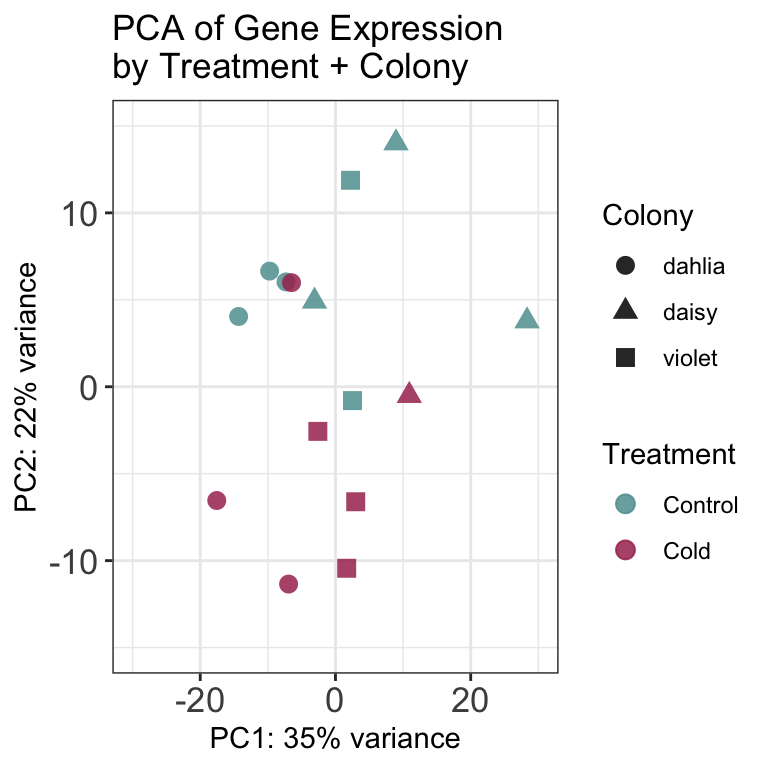

### Volcano Plot of Gene Expression, 30-min Sample

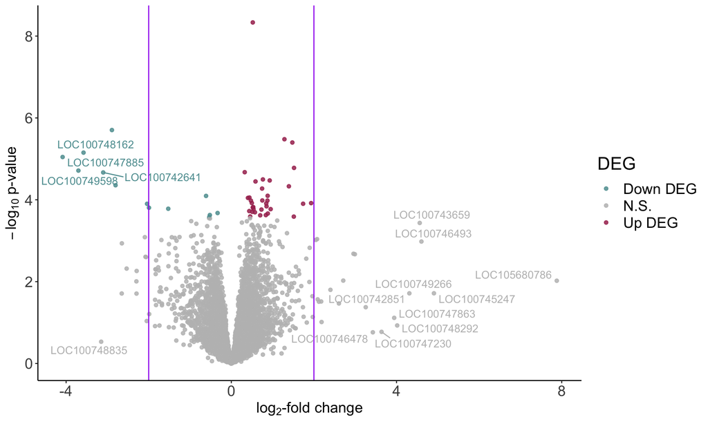

#### This volcano plot looks **SO** much better! This is much more like what a canonical volcano plot looks like.